# Analyzing Global Happiness from 2005 to 2021

#### Shijia Liao, Sijia Hua, Hongyang Lin

## Outline

1. Introduction
   - 1.1 Import Library
2. Data
   - 2.1 Source of Data
   - 2.2 Explanation of Terms
   - 2.3 Import data and preview
3. Data Analysis
   - 3.1 Data Visualization
     - 3.1.1 Visualize the Life Ladder
     - 3.1.2 GDP and Life Ladder
   - 3.2 Explore the pattern
   - 3.3 Find out the strongest correlation factor
4. Machine Learning Algorithm
   - 4.1 Data Preparing
   - 4.2 Fit The Model
   - 4.3 Explain The Model
5. Conclusion
   - 5.1 Review
   - 5.2 Result

## 1 Introduction

In this project, we are going to analyze the world happiest report. From this report, we are going to try to analyze how can we determine a country with highest level of "happiness". We are going to visualize the data and examine the relationship between each factors that will influence the happiness.

### 1.1 Import Library

- math: Math library that helps with the calculation
- sklearn: Efficient tools for predictive data analysis
- pandas (pd): Use dataframes to import, view, and analyze the data.
- numpy (np): Perform necessary math operations over the data.
- matplotlib.pyplot (plt): Create plots for data analysis.
- Seaborn (sns): Create plots for data analysis

```python
import math
import sklearn
from sklearn import preprocessing, model_selection, linear_model
import pandas as pd
import numpy as np
import matplotlib.pyplot as plt
import seaborn as sns

sns.set_theme()
```

## 2 Data

### 2.1 Source of data

The data we are going to use in this report is from: https://www.kaggle.com/ajaypalsinghlo/world-happiness-report-2021

The original data for this dataset is from: https://worldhappiness.report/

In this dataset, there are two csv files, which contain world happiest data from past years and this year.

### 2.2 Explanation of Terms

All of the following data explanations are from [Official FAQ website](https://worldhappiness.report/faq/)

Life Ladder(Ladder score): Measurement of happiness from value from 0 to 10. According to the official, the dataset has a sample size of 2,000 to 3,000 at the national level.

There are six factors that are measured to form the result of Life Ladder:

- Log [GDP](https://en.wikipedia.org/wiki/Gross_domestic_product) per capita: A measurement of the economy growth of a country.
- Life expectency: An estimation of number of years that a person can live.
- Generosity: A measurement of people's kindness level.
- Social Support: A social system that provides people with assistence and comfort.
- Freedom: The power or right to act, speak, and think as one wants.
- Corruption: Misconduct or illegal behaviors of people in power.

### 2.3 Import data and preview

To start with the project, we need to load the data from the dataset. To concat the data from 2021 and past years, we rename some of the columns. Those data are loaded into 3 dataframes:

- data_2021: data from the 2021 report file
- data_historical: data from the past years report file
- df: Combined data of data_2021 and data_historical with main information

```python
# Load data from csv
data_historical = pd.read_csv("dataset/world-happiness-report.csv")
data_2021 = pd.read_csv("dataset/world-happiness-report-2021.csv")

# Tranfrom data of 2021's format to historical
data_2021 = data_2021.rename(columns={
    "Ladder score": "Life Ladder",
    "Logged GDP per capita": "Log GDP per capita",
    "Healthy life expectancy": "Healthy life expectancy at birth"
})

# Set year
data_2021['year'] = 2021

# Concat dataframes
data = pd.concat([data_historical, data_2021])

# Pick columns we need
df = data[[
    "Country name", "year", "Life Ladder", "Log GDP per capita", "Social support",
    "Healthy life expectancy at birth", "Freedom to make life choices", "Generosity", "Perceptions of corruption"
]]

# Drop the rows with NaN
df = df.dropna()

# Preview our data
df
```

|  | Country name | year | Life Ladder | Log GDP per capita | Social support | Healthy life expectancy at birth | Freedom to make life choices | Generosity | Perceptions of corruption |
| --- | --- | --- | --- | --- | --- | --- | --- | --- | --- |
| 0 | Afghanistan | 2008 | 3.724 | 7.370 | 0.451 | 50.800 | 0.718 | 0.168 | 0.882 |
| 1 | Afghanistan | 2009 | 4.402 | 7.540 | 0.552 | 51.200 | 0.679 | 0.190 | 0.850 |
| 2 | Afghanistan | 2010 | 4.758 | 7.647 | 0.539 | 51.600 | 0.600 | 0.121 | 0.707 |
| 3 | Afghanistan | 2011 | 3.832 | 7.620 | 0.521 | 51.920 | 0.496 | 0.162 | 0.731 |
| 4 | Afghanistan | 2012 | 3.783 | 7.705 | 0.521 | 52.240 | 0.531 | 0.236 | 0.776 |
| ... | ... | ... | ... | ... | ... | ... | ... | ... | ... |
| 144 | Lesotho | 2021 | 3.512 | 7.926 | 0.787 | 48.700 | 0.715 | -0.131 | 0.915 |
| 145 | Botswana | 2021 | 3.467 | 9.782 | 0.784 | 59.269 | 0.824 | -0.246 | 0.801 |
| 146 | Rwanda | 2021 | 3.415 | 7.676 | 0.552 | 61.400 | 0.897 | 0.061 | 0.167 |
| 147 | Zimbabwe | 2021 | 3.145 | 7.943 | 0.750 | 56.201 | 0.677 | -0.047 | 0.821 |
| 148 | Afghanistan | 2021 | 2.523 | 7.695 | 0.463 | 52.493 | 0.382 | -0.102 | 0.924 |

1861 rows × 9 columns

#### A preview of the overall data

```python
df.describe(include='all')
```

|  | Country name | year | Life Ladder | Log GDP per capita | Social support | Healthy life expectancy at birth | Freedom to make life choices | Generosity | Perceptions of corruption |
| --- | --- | --- | --- | --- | --- | --- | --- | --- | --- |
| count | 1861 | 1861.000000 | 1861.000000 | 1861.000000 | 1861.000000 | 1861.000000 | 1861.000000 | 1861.000000 | 1861.000000 |
| unique | 161 | NaN | NaN | NaN | NaN | NaN | NaN | NaN | NaN |
| top | Georgia | NaN | NaN | NaN | NaN | NaN | NaN | NaN | NaN |
| freq | 16 | NaN | NaN | NaN | NaN | NaN | NaN | NaN | NaN |
| mean | NaN | 2013.896830 | 5.452041 | 9.328915 | 0.810520 | 63.360022 | 0.743653 | -0.001872 | 0.749219 |
| std | NaN | 4.437147 | 1.131143 | 1.158199 | 0.121138 | 7.624643 | 0.141286 | 0.161176 | 0.185398 |
| min | NaN | 2005.000000 | 2.375000 | 6.635000 | 0.290000 | 32.300000 | 0.258000 | -0.335000 | 0.035000 |
| 25% | NaN | 2010.000000 | 4.609000 | 8.399000 | 0.741000 | 58.300000 | 0.649000 | -0.112000 | 0.695000 |
| 50% | NaN | 2014.000000 | 5.371000 | 9.460000 | 0.834000 | 65.200000 | 0.763000 | -0.027000 | 0.804000 |
| 75% | NaN | 2018.000000 | 6.255000 | 10.291000 | 0.907000 | 68.800000 | 0.857000 | 0.088000 | 0.871000 |
| max | NaN | 2021.000000 | 7.971000 | 11.648000 | 0.987000 | 77.100000 | 0.985000 | 0.689000 | 0.983000 |

## 3 Data Analysis

### 3.1 Data Visualization

In this part, we are going to visualize the some of the data in the dataset. Some plots are not drawn since the plot do not show any direct relationships between Life Ladder and the factor.

#### 3.1.1 Visualize the Life Ladder

First, let's take a look at the life ladder in 2021. The plot below is a visualization of the life ladder. Its y-axis shows the country name, and the x-axis shows the corresponding Life Ladder score.

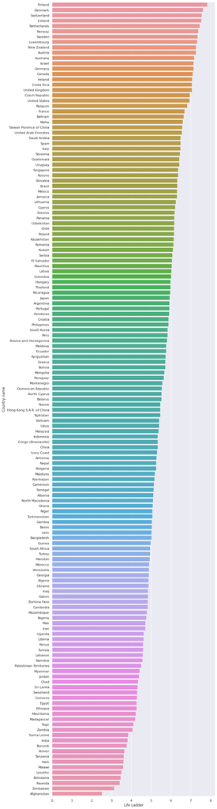

```python
plt.figure(figsize=(10, 50))
sns.barplot(data = data_2021, x="Life Ladder",y="Country name")
```

How about the overall Life Ladder across all years in the both dataset. The following plot is a plot with ascending country name.

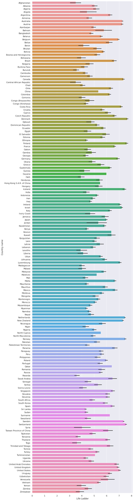

```python
plt.figure(figsize=(10, 50))
sns.barplot(data = df.sort_values(by='Country name'), x="Life Ladder",y="Country name")
```

From the graph about, most country has similiar life ladder in recent years, except some countries, such as Congo, Angola, Afghanistan, Benin, and so on. Most of them are located in central africa and most of them are having war during this period of time. In the next part, we are going to show the Life Ladder based on the region using the data in 2021.

However, before analyzing the regional data, we need to know the distribution of countries in different region.

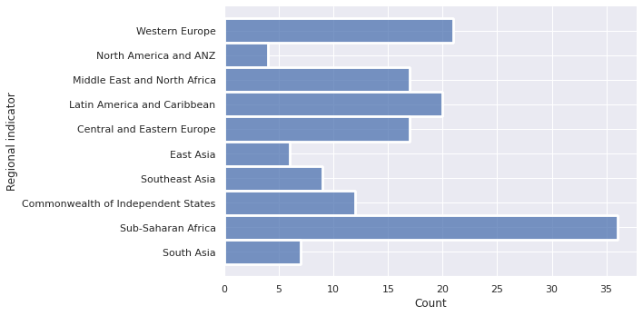

```python
sns.displot(data=data_2021, y='Regional indicator', aspect=2)
```

The second plot, shows the same data but in a different way. By using stack, we can clearly see how many countries for each regional in each bar clearly. It is hard to notice that south asia is also having a low life ladder due to its low sample size compare to Sub-Saharan countries. From the stack graph, we can clearly see that South Asia also has a low Life Ladder score.

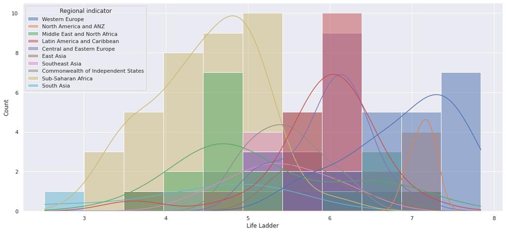

```python
plt.figure(figsize=(18,8))
sns.histplot(data = data_2021, x = "Life Ladder", kde=True, hue="Regional indicator")
```

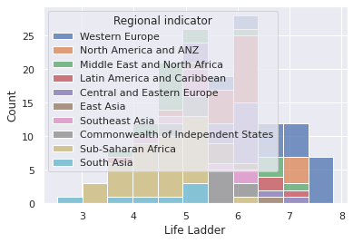

```python
sns.histplot(data = data_2021, x = "Life Ladder", hue="Regional indicator", multiple='stack')
```

#### 3.1.2 GDP and Life Ladder

Based on the description in the dataset, GDP is a factor that determines the value of Life Ladder. To show the relationship, we first choose to show a scatterplot of GDP and Life Ladder.

The first plot, which shows the relationship between GDP and Life Ladder. Based on the plot, we can see that Life Ladder is increasing as the GDP of a country increases.

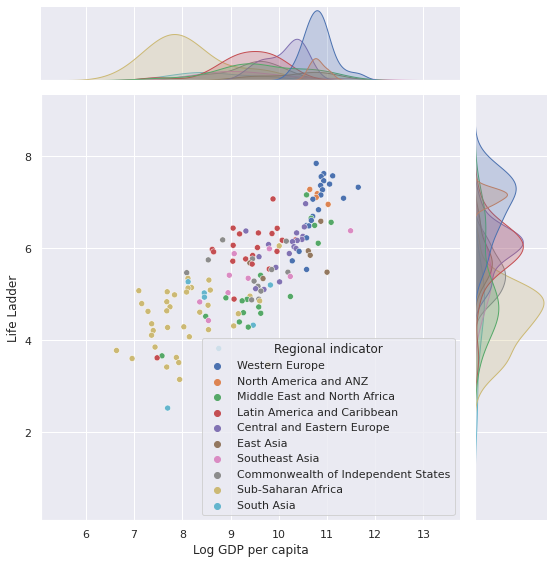

```python
sns.jointplot(data=data_2021, x = "Log GDP per capita", y="Life Ladder", hue="Regional indicator", height=8)
```

But, how about the general data? The second plot shows the relationship between GDP and Life Ladder, without considering the factor of country name, years (which means that the same country in different years are also plotted in the graph). Based on the graph, we can generally say that GDP has a positive effect on the overall Life Ladder. However, it is hard to say whether the data has a linear relationship between those two factors.

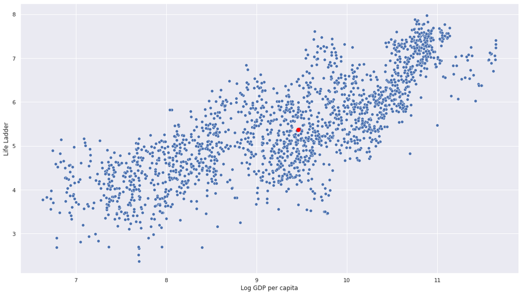

```python
plt.figure(figsize=(18,10))
sns.scatterplot(data=df, x = "Log GDP per capita", y="Life Ladder")
plt.plot(df['Log GDP per capita'].median(), df['Life Ladder'].median(), '.' ,color = 'red', markersize=15)
```

### 3.2 Explore the pattern

First, find out if the happiness index (Life Ladder score) is consistent throughout years 2005-2021.

- Determine this by finding out countries that are within top 50 Life Ladder score
- Check out the pattern
- Summarize the trend of happiness ranking changes for result countries

```python
# display countries within top 50 Life Ladder in each year
init = list(range(50))
top50 = pd.DataFrame(index = init, columns=np.unique(df['year']))
sort = df.sort_values('Life Ladder', ascending=False)

# group all information by year and retrieve the result
for year, info in sort.groupby('year'):
    count = 0
    for country in np.array(info['Country name'].head(50)):
        top50.at[count, year] = country
        count += 1

# demonstrate result
top50.iloc[: , 1:]
```

|  | 2006 | 2007 | 2008 | 2009 | 2010 | 2011 | 2012 | 2013 | 2014 | 2015 | 2016 | 2017 | 2018 | 2019 | 2020 | 2021 |
| --- | --- | --- | --- | --- | --- | --- | --- | --- | --- | --- | --- | --- | --- | --- | --- | --- |
| 0 | Finland | Denmark | Denmark | Denmark | Denmark | Denmark | Switzerland | Canada | Denmark | Norway | Finland | Finland | Finland | Finland | Finland | Finland |
| 1 | Switzerland | New Zealand | Finland | Costa Rica | Canada | Netherlands | Norway | Denmark | Switzerland | Switzerland | Norway | Denmark | Denmark | Switzerland | Iceland | Denmark |
| 2 | Norway | Netherlands | Norway | Switzerland | Netherlands | Austria | Iceland | Iceland | Norway | Denmark | Denmark | Norway | Switzerland | Denmark | Denmark | Switzerland |
| 3 | New Zealand | Costa Rica | Netherlands | Canada | Sweden | Israel | Sweden | Austria | Israel | Iceland | Netherlands | Iceland | Netherlands | Norway | Switzerland | Iceland |
| 4 | Ireland | Australia | Ireland | Israel | Venezuela | Canada | Denmark | Finland | Finland | Finland | Iceland | Switzerland | Norway | Netherlands | Netherlands | Netherlands |
| 5 | Austria | Sweden | Sweden | Sweden | Australia | Australia | Netherlands | Mexico | Netherlands | New Zealand | Switzerland | Netherlands | Austria | Luxembourg | Sweden | Norway |
| 6 | Costa Rica | Belgium | Canada | Venezuela | Finland | Sweden | Finland | Sweden | New Zealand | Canada | Sweden | Canada | Sweden | Sweden | Germany | Sweden |
| 7 | United Arab Emirates | Spain | New Zealand | United States | Israel | Finland | Canada | Netherlands | Canada | Netherlands | Australia | Israel | New Zealand | Israel | Norway | Luxembourg |
| 8 | France | Panama | Spain | Ireland | Panama | Panama | Austria | Australia | Australia | Australia | Canada | New Zealand | Luxembourg | Ireland | New Zealand | New Zealand |
| 9 | Venezuela | Israel | United States | Panama | Austria | Costa Rica | Mexico | Israel | Costa Rica | Sweden | New Zealand | Austria | United Kingdom | Australia | Austria | Austria |
| 10 | Argentina | Singapore | Israel | Brazil | Costa Rica | New Zealand | Costa Rica | New Zealand | Sweden | Israel | Israel | Sweden | Australia | New Zealand | Israel | Australia |
| 11 | Cyprus | United Kingdom | Australia | Mexico | Ireland | United States | New Zealand | United States | United States | Austria | Costa Rica | Australia | Canada | Austria | Australia | Israel |
| 12 | Jamaica | Greece | Austria | Luxembourg | New Zealand | Belgium | Australia | Costa Rica | Singapore | Germany | Austria | Costa Rica | Costa Rica | United Kingdom | Ireland | Germany |
| 13 | Taiwan Province of China | Italy | Belgium | United Kingdom | United States | Luxembourg | Israel | Brazil | Ireland | Belgium | Ireland | United Kingdom | Germany | Canada | United States | Canada |
| 14 | Panama | Mexico | France | United Arab Emirates | Luxembourg | Brazil | Venezuela | Luxembourg | Thailand | United States | Luxembourg | Germany | Czech Republic | Germany | Canada | Ireland |
| 15 | Kuwait | Czech Republic | United Kingdom | El Salvador | United Arab Emirates | Ireland | United States | Belgium | Germany | Costa Rica | Belgium | Luxembourg | Ireland | Costa Rica | Czech Republic | Costa Rica |
| 16 | Chile | Belize | Panama | Cyprus | United Kingdom | France | Ireland | Germany | Brazil | Ireland | Germany | Ireland | Israel | United States | Belgium | United Kingdom |
| 17 | Colombia | Germany | Iceland | Germany | Belgium | South Korea | Luxembourg | United Kingdom | Austria | Luxembourg | United Kingdom | United States | Malta | Belgium | United Kingdom | Czech Republic |
| 18 | Malaysia | Guatemala | Costa Rica | Kuwait | Brazil | Mexico | Belgium | Panama | Luxembourg | Argentina | Mexico | Belgium | Belgium | Malta | France | United States |
| 19 | Lithuania | Brazil | Mexico | Chile | Mexico | United Kingdom | United Kingdom | Ireland | Belgium | Uruguay | United States | Czech Republic | United States | France | Slovakia | Belgium |
| 20 | Guatemala | Malaysia | Saudi Arabia | Guatemala | France | Argentina | Panama | Chile | Chile | Singapore | Czech Republic | Malta | France | Slovenia | Croatia | France |
| 21 | Thailand | Japan | Italy | Argentina | Kuwait | Cyprus | Germany | Czech Republic | United Kingdom | Malta | Malta | France | Guatemala | Uruguay | Spain | Bahrain |
| 22 | Trinidad and Tobago | Colombia | Trinidad and Tobago | Qatar | El Salvador | Thailand | France | France | Mexico | Czech Republic | Chile | Panama | Mexico | Spain | Italy | Malta |
| 23 | Slovenia | Argentina | Brazil | Italy | Germany | Germany | Chile | Colombia | Argentina | Panama | France | Nicaragua | Italy | El Salvador | Slovenia | Taiwan Province of China |
| 24 | Uruguay | Guyana | Singapore | Uruguay | Chile | Venezuela | Argentina | Argentina | Panama | Brazil | Argentina | Uzbekistan | Spain | Brazil | Estonia | United Arab Emirates |
| 25 | El Salvador | Poland | Guatemala | France | Singapore | Singapore | Uruguay | Venezuela | Uruguay | Chile | Brazil | Mexico | Chile | Italy | Lithuania | Saudi Arabia |
| 26 | Belarus | Croatia | Venezuela | Colombia | Argentina | Uruguay | Colombia | Singapore | Guatemala | United Kingdom | Guatemala | Singapore | Singapore | Mexico | Uruguay | Spain |
| 27 | Kazakhstan | Lithuania | Colombia | Spain | Colombia | Chile | Czech Republic | Uruguay | Czech Republic | Guatemala | Spain | Slovakia | Uruguay | Singapore | Kyrgyzstan | Italy |
| 28 | Portugal | Thailand | Argentina | Saudi Arabia | Cyprus | Trinidad and Tobago | Thailand | El Salvador | France | Colombia | Colombia | El Salvador | Lithuania | Colombia | Latvia | Slovenia |
| 29 | Honduras | South Korea | Japan | Singapore | Italy | Spain | Spain | Thailand | Spain | Spain | Uruguay | Uruguay | Panama | Jamaica | Kazakhstan | Guatemala |
| 30 | Bolivia | Kazakhstan | Kazakhstan | Bolivia | Guatemala | Colombia | Suriname | Trinidad and Tobago | Malta | France | Poland | Brazil | Cyprus | Kazakhstan | Chile | Uruguay |
| 31 | Estonia | Chile | Malaysia | Greece | Czech Republic | Czech Republic | Cyprus | Spain | Colombia | Malaysia | El Salvador | Guatemala | Slovenia | Philippines | Poland | Singapore |
| 32 | South Korea | Uruguay | Chile | Honduras | Taiwan Province of China | Japan | Slovenia | Ecuador | Nicaragua | Mexico | Panama | Chile | El Salvador | Guatemala | Japan | Kosovo |
| 33 | Slovakia | Pakistan | Portugal | Ecuador | Thailand | Italy | Croatia | Italy | Slovakia | Thailand | Ecuador | Lithuania | Slovakia | Slovakia | Brazil | Slovakia |
| 34 | Uzbekistan | Bolivia | Uruguay | Jordan | Spain | Slovenia | Bolivia | Guatemala | Venezuela | Slovakia | Thailand | Spain | Uzbekistan | Poland | Serbia | Brazil |
| 35 | Moldova | Turkey | Thailand | Japan | South Korea | Slovakia | Uzbekistan | Slovenia | Lithuania | El Salvador | Singapore | Poland | Brazil | Serbia | Hungary | Mexico |
| 36 | Dominican Republic | Belarus | Russia | Slovenia | Slovenia | Peru | Moldova | Japan | Uzbekistan | Moldova | Nicaragua | Italy | Romania | Mauritius | Mauritius | Jamaica |
| 37 | Laos | Jordan | Paraguay | Poland | Uruguay | Albania | Ecuador | South Korea | Russia | Poland | Slovakia | Trinidad and Tobago | Ecuador | Uzbekistan | Mongolia | Lithuania |
| 38 | Ecuador | Vietnam | Lithuania | Bahrain | Japan | Ecuador | El Salvador | Uzbekistan | Italy | Russia | South Korea | Mauritius | Poland | Cyprus | Mexico | Cyprus |
| 39 | Russia | Romania | Taiwan Province of China | South Korea | Slovakia | Moldova | Malaysia | Slovakia | Kazakhstan | Uzbekistan | Romania | Slovenia | Estonia | Romania | Argentina | Estonia |
| 40 | Indonesia | Laos | Moldova | Paraguay | Bahrain | Malaysia | Slovakia | Paraguay | Malaysia | Ecuador | Italy | Colombia | Thailand | Nicaragua | Thailand | Panama |
| 41 | Zambia | Iran | Vietnam | Belarus | Poland | Bolivia | Poland | Croatia | Belize | Kazakhstan | Japan | Romania | Kazakhstan | Portugal | Moldova | Uzbekistan |
| 42 | Peru | Estonia | Belarus | Moldova | Honduras | Vietnam | Guatemala | Belarus | Ecuador | Nicaragua | Latvia | Hungary | Colombia | Panama | South Korea | Chile |
| 43 | Ukraine | El Salvador | Estonia | Peru | Paraguay | Guatemala | Italy | Kazakhstan | Japan | Latvia | Slovenia | Cyprus | Hungary | Argentina | Greece | Poland |
| 44 | Botswana | Paraguay | Botswana | Albania | Greece | Uzbekistan | Peru | Peru | Moldova | Japan | Lithuania | Argentina | Serbia | Lithuania | Portugal | Kazakhstan |
| 45 | Paraguay | Ukraine | Honduras | Thailand | Ecuador | Kazakhstan | Paraguay | Nicaragua | Peru | Italy | Russia | Honduras | Portugal | Estonia | Montenegro | Romania |
| 46 | Azerbaijan | Russia | South Korea | Indonesia | Pakistan | Paraguay | Lithuania | Malaysia | Bolivia | Bolivia | Paraguay | Latvia | Bolivia | Thailand | Colombia | Kuwait |
| 47 | Latvia | Ghana | South Africa | Lithuania | Bolivia | Poland | Kazakhstan | Bolivia | El Salvador | South Korea | Cyprus | Thailand | Honduras | Bosnia and Herzegovina | Bulgaria | Serbia |
| 48 | Nigeria | Peru | Syria | Croatia | Nicaragua | Ghana | Libya | Moldova | Belarus | Romania | Bolivia | Estonia | Latvia | Dominican Republic | Bolivia | El Salvador |
| 49 | Philippines | South Africa | Bolivia | Dominican Republic | Peru | Angola | Belarus | Poland | South Korea | Slovenia | Serbia | Japan | Bosnia and Herzegovina | Hungary | Bosnia and Herzegovina | Mauritius |

```python
# Filter out countries that stay within the top 50 Life Ladder score
# for at least 15 years of the time period during 2005-2021
total = []
res = []
unique = []

for i in range(2005, 2022):
    for ele in list(top50[i]):
        total.append(ele)

# filter out a unique list from all counries
unique = np.unique(total)
for e in unique:
    if total.count(e) >= 15:
        res.append(e)

print(f"There are {len(res)} countries that stay within the top 50 Life Ladder score for at least 15 years.")
```

```
There are 18 countries that stay within the top 50 Life Ladder score for at least 15 years.
```

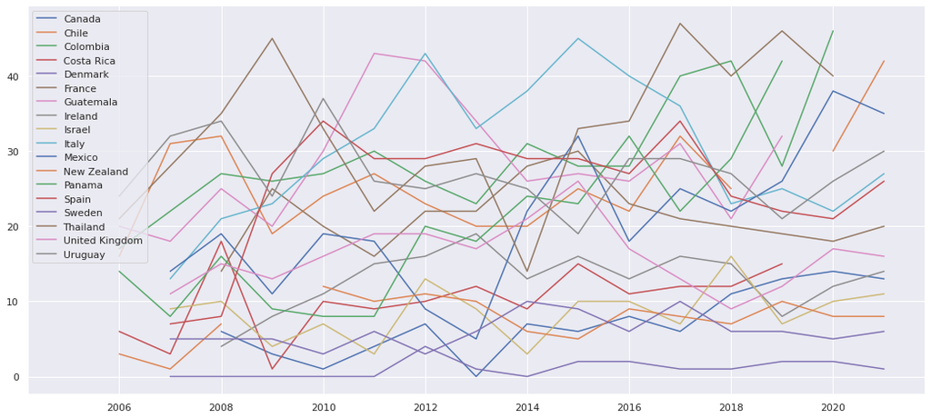

```python
plot = []
count = 0

# build a list for rankings of countries each year,
# use nan to represent years that these countries are not in top50.
for country in res:
    tmp = []
    for i in range(2005, 2022):
        if len(list(np.where(top50[i] == country)[0])) > 0:
            tmp.append(list(np.where(top50[i] == country)[0])[0])
        else:
            tmp.append(math.nan)
    plot.append(tmp)

# Use a line plot to show the trend of countries Ladder Score,
# and label each line with corresponding country
# nan will not show up on the graph
x = list(range(2005, 2022))
plt.rcParams["figure.figsize"] = [18, 8]
for y in plot:
    plt.plot(x, y, label=res[count])
    count += 1
plt.legend()
```

Then, according to the plot, most countries that stay within top 50 Life Ladder Score show very unstable rankings. Only a few of them maintain a consistent ranking thoughout 2005-2021.

Given the above two observations, we conclude that it's not easy for countries to stay happy. Therefore, it's meaningful to find out what factors are impacting the Life Ladder score, and what countries should focus on in order to improve or maintain their happiness status.

The next step will be finding out which factor(out of the six factors listed above) has the most noticeable impact on Life Ladder Score.

### 3.3 Find out the strongest correlation factor

```python
# create a dataframe for calculating correlation between Life Ladder and other factors
tst = df[['Life Ladder', 'Log GDP per capita',"Social support",
    "Healthy life expectancy at birth", "Freedom to make life choices", "Generosity", "Perceptions of corruption"]]
correlation = tst.corr()
correlation = correlation[['Life Ladder']].iloc[1:]
correlation
```

|  | Life Ladder |
| --- | --- |
| Log GDP per capita | 0.792883 |
| Social support | 0.716334 |
| Healthy life expectancy at birth | 0.755219 |
| Freedom to make life choices | 0.527932 |
| Generosity | 0.167365 |
| Perceptions of corruption | -0.446846 |

According to the calculation result from above, we can tell that Log GDP per capita has the strongest correlation to Life Ladder score compared to other factors listed.

In the next section, we will use machine learning (linear model) to find out more specifc impact that these factors have on Life Ladder score. We will compare the result with the current one calculated from the dataframe and find out if Log GDP per capita is still the most "correlated" factor.

## 4 Machine Learning Algorithm

In this section, we will use machine learning algorithm, the linear regression, to create a model to predict the relationship between parmas and life ladder.  
This model can help us to know the correlation between these parmaters and the life ladder. What's more, we can also find the impact each paramater.

### 4.1 Data Preparing

Before using linear regression model to predict the result, we need to preprocess the data so that we can feed them into our model.  
Since we want to figure out the impact of each paramater, we need to scale (standardize) them into same range.

```python
# First, we need to specify the paramaters (keys)
keys = [
    "Log GDP per capita", "Social support",
    "Healthy life expectancy at birth", "Freedom to make life choices", "Generosity", "Perceptions of corruption"
]

# Then, to avoid the singificant variance of coef caused by params' range, I need to scale them
scaler = preprocessing.RobustScaler()
X = scaler.fit_transform(df[keys])
Y = df['Life Ladder']

# Print current data's shape
print("Data shape", X.shape, Y.shape)

# Show scaled data
partial_df = df[keys].copy()
partial_df[keys] = X
partial_df
```

```
Data shape (1861, 6) (1861,)
```

|  | Log GDP per capita | Social support | Healthy life expectancy at birth | Freedom to make life choices | Generosity | Perceptions of corruption |
| --- | --- | --- | --- | --- | --- | --- |
| 0 | -1.104651 | -2.307229 | -1.371429 | -0.216346 | 0.975 | 0.443182 |
| 1 | -1.014799 | -1.698795 | -1.333333 | -0.403846 | 1.085 | 0.261364 |
| 2 | -0.958245 | -1.777108 | -1.295238 | -0.783654 | 0.740 | -0.551136 |
| 3 | -0.972516 | -1.885542 | -1.264762 | -1.283654 | 0.945 | -0.414773 |
| 4 | -0.927590 | -1.885542 | -1.234286 | -1.115385 | 1.315 | -0.159091 |
| ... | ... | ... | ... | ... | ... | ... |
| 144 | -0.810782 | -0.283133 | -1.571429 | -0.230769 | -0.520 | 0.630682 |
| 145 | 0.170190 | -0.301205 | -0.564857 | 0.293269 | -1.095 | -0.017045 |
| 146 | -0.942918 | -1.698795 | -0.361905 | 0.644231 | 0.440 | -3.619318 |
| 147 | -0.801797 | -0.506024 | -0.857048 | -0.413462 | -0.100 | 0.096591 |
| 148 | -0.932875 | -2.234940 | -1.210190 | -1.831731 | -0.375 | 0.681818 |

1861 rows × 6 columns

Then I need to split the dataset

```python
X_train, X_test, Y_train, Y_test = model_selection.train_test_split(X, Y, test_size=0.1)
print('We have', X_train.shape[0], 'train samples, and', X_test.shape[0], 'test samples')
```

```
We have 1674 train samples, and 187 test samples
```

### 4.2 Fit The Model

In this section, we will use Linear Regression to fit a model based on our dataset.

```python
linear_regressor = linear_model.LinearRegression()
# Regression based on training dataset
linear_regressor.fit(X_train, Y_train)

# Test accuracy on both training and testing dataset
accuracy_train = linear_regressor.score(X_train, Y_train)
accuracy_test = linear_regressor.score(X_test, Y_test)

print(f"The accuracy on training dataset is {accuracy_train:.4f}")
print(f"The accuracy on testing dataset is {accuracy_test:.4f}")
```

```
The accuracy on training dataset is 0.7537
The accuracy on testing dataset is 0.7337
```

Because the accuracy on the both training and testing dataset is higher than 0.7, our model can indicate the relationship between params and the life ladder with high confidence.

### 4.3 Explain The Model

In this section, we will use two plots to visualize and explain the model.

```python
# Use coef to find the impact of different param
for index, key in enumerate(keys):
    print(f"The impact coefficient of {key} is {linear_regressor.coef_[index]:.4f}")
```

```
The impact coefficient of Log GDP per capita is 0.6872
The impact coefficient of Social support is 0.3895
The impact coefficient of Healthy life expectancy at birth is 0.2999
The impact coefficient of Freedom to make life choices is 0.2248
The impact coefficient of Generosity is 0.1350
The impact coefficient of Perceptions of corruption is -0.1102
```

Since this impact result is not intuitive enough, I will create a pie chart to visualize impacts.

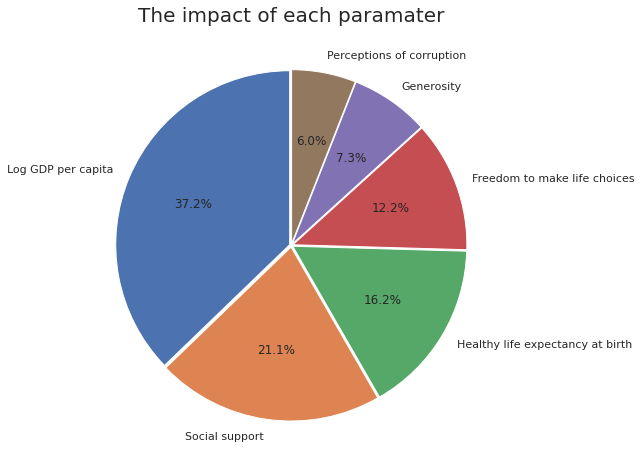

```python
plt.pie(
    np.abs(linear_regressor.coef_[:len(keys)]), explode=[0.01]*len(keys),
    labels=keys, autopct='%1.1f%%', startangle=90
)
plt.title("The impact of each paramater", size=20)
plt.show()
```

Then, a residue plot can help use to know whether our model can effectively interpret the data.

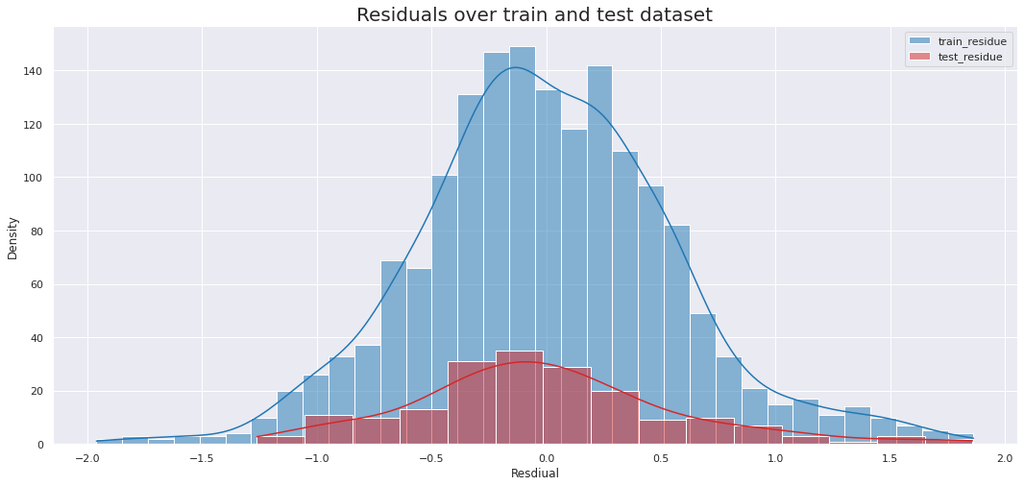

```python
# Get residues
train_residue = linear_regressor.predict(X_train) - Y_train
test_residue = linear_regressor.predict(X_test) - Y_test

# Use histplot to plot them
sns.histplot(train_residue, kde=True, label='train_residue', color='tab:blue')
sns.histplot(test_residue, kde=True, label='test_residue', color='tab:red')

# Add plot descriptions
plt.xlabel("Resdiual")
plt.ylabel("Density")
plt.title("Residuals over train and test dataset", size=20)
plt.legend()
plt.show()
```

From this plot, we can find that both train residue and test residue follow a normal distribution centered at 0. This indicates that our model can explain the outcome effectively.

## 5 Conclusion

### 5.1 Review

In this tutorial, we find the impact of GDP, life expectancy, generosity, social support, freedom, and corruption on happiness using a world happiness dataset from Kaggle. In section 2, since historical data and data in 2021 have different formats, we convert the data into the same format. In section 3, we visualize some plots which can show relationships between Life Ladder (happiness) and the parameters. And we find that GDP plays an important role in Life Ladder. In section 4, we use a machine-learning algorithm, linear regression, to model the Life Ladder based on the parameters we mentioned above. Since the residuals are normally distributed, our model can explain the relationship between life ladder and other parameters. And the factors in linear regression support our view that GDP plays the most important role.

### 5.2 Result

From the graphs and analysis, we can see that for countries in the Western Europe, they have the highest happiness (Life Ladder) score. In contrast, those countries in Sub-Saharan Africa has the lowest happiness score. Among all the factors that is considered while measuring the happiness data in section 3 and 4, GDP plays the most important role, along with social support and life expectency.